# Dolcetto control guides

```python
import pandas as pd
import numpy as np
import matplotlib.pyplot as plt
import seaborn as sns
import warnings

warnings.filterwarnings('ignore')
```

## Finding essential control guides for CRISPRi using exisiting Dolcetto data

The Dolcetto Set A data from Sanson et al., 2019 was used in this analysis. The average log-fold change of 3 replicates for HT29 and A375 was calculated. The essential genes list from Hart et al., 2015 and non-essential genes list from Hart et al., 2014 was used to determine guides targeting essential and non-essential genes.

```python
dol = pd.read_excel('inputs/Dolcetto_SetA_data.xlsx', sheet_name='Log-fold change')
dol['HT29_Avg'] = dol[['HT29_RepA','HT29_RepB','HT29_RepC']].mean(axis=1)
dol['A375_Avg'] = dol[['A375_RepA','A375_RepB','A375_RepC']].mean(axis=1)
dol_cp = pd.read_excel('metadata/SupplementaryData3_Dolcetto_v2.xlsx', sheet_name='SetA sgRNA annotations')
dol = pd.merge(dol, dol_cp, on='sgRNA Sequence')
ctrls = dol[dol['Annotated Gene Symbol'] == 'CONTROL']
non_ctrls = dol[dol['Annotated Gene Symbol'] != 'CONTROL']
```

```python
ess_genes = pd.read_csv('inputs/essential-genes.txt', sep='\t', header=None)
ess_genes.columns = ['Annotated Gene Symbol']
```

```python
non_ess = pd.read_csv('inputs/non-essential-genes.txt', sep='\t', header=None)
non_ess.columns = ['Annotated Gene Symbol']
```

```python
dol_ess = pd.merge(dol, ess_genes, on='Annotated Gene Symbol')
dol_non_ess = pd.merge(dol, non_ess, on='Annotated Gene Symbol')
```

### A375 data

The distribution of essential and non-essential guides from the A375 data is shown below. The black dashed line is the 1th percentile of non-essential guides. 1809 essential guides with log-fold changes < 1th percentile of non-essential guides are considered "good" essential guides.

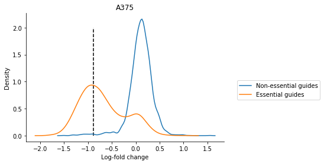

```python
g = sns.distplot(dol_non_ess.A375_Avg, hist=False, label='Non-essential guides')
g = sns.distplot(dol_ess.A375_Avg, hist=False, label='Essential guides')
a375_per_1 = np.percentile(dol_non_ess.A375_Avg, 1)
plt.vlines(a375_per_1, 0.0, 2.0, linestyles='dashed')
plt.legend(loc='upper right',bbox_to_anchor=(1.5,0.5))
plt.title('A375')
plt.ylabel('Density')
plt.xlabel('Log-fold change')
sns.despine()
```

```python
a375_tru_ess = dol_ess[dol_ess.A375_Avg < a375_per_1]
```

### HT29 data

The distribution of essential and non-essential guides from the HT29 data is shown below. The black dashed line is the 1th percentile of non-essential guides. 2356 essential guides with log-fold changes < 1th percentile of non-essential guides are considered "good" essential guides.

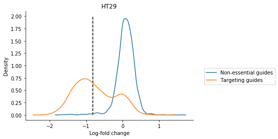

```python
g = sns.distplot(dol_non_ess.HT29_Avg, hist=False, label='Non-essential guides')
g = sns.distplot(dol_ess.HT29_Avg, hist=False, label='Targeting guides')
ht29_per_1 = np.percentile(dol_non_ess.HT29_Avg, 1)
plt.vlines(ht29_per_1, 0.0, 2.0, linestyles='dashed')
plt.legend(loc='upper right',bbox_to_anchor=(1.5,0.5))
plt.title('HT29')
plt.ylabel('Density')
plt.xlabel('Log-fold change')
sns.despine()
```

```python
ht29_tru_ess = dol_ess[dol_ess.HT29_Avg < ht29_per_1]
```

The 1625 "good" essential guides that were common to both A375 and HT29 data were included in the CRISPRi essential control guides list.

```python
common_tru = pd.merge(a375_tru_ess, ht29_tru_ess, on='sgRNA Sequence')
```

```python
common_tru[['sgRNA Sequence', 'Annotated Gene Symbol_x', 'A375_Avg_x', 'HT29_Avg_x']].to_csv('Dolcetto_essential_control_guides.txt', sep='\t', index=False)
```